# IntroComp_Weixuan_HW7

Weixuan Chen

3/7/2023

```r
library(ggplot2)
library(dplyr)
```

## Data Preparation

```r
ageIQ <- tibble::tribble(~Age, ~IQ, 23L, 100L, 18L, 105L, 10L, 95L, 45L, 120L)
ageIQ.s <- cbind(ageIQ, Sums = rowSums(ageIQ))
ageIQ.s <- rbind(ageIQ.s, Sums = colSums(ageIQ.s))
summary(ageIQ)
```

```
##       Age             IQ
##  Min.   :10.0   Min.   : 95.00
##  1st Qu.:16.0   1st Qu.: 98.75
##  Median :20.5   Median :102.50
##  Mean   :24.0   Mean   :105.00
##  3rd Qu.:28.5   3rd Qu.:108.75
##  Max.   :45.0   Max.   :120.00
```

## 1

```r
ageIQ
```

```
## # A tibble: 4 × 2
##     Age    IQ
##   <int> <int>
## 1    23   100
## 2    18   105
## 3    10    95
## 4    45   120
```

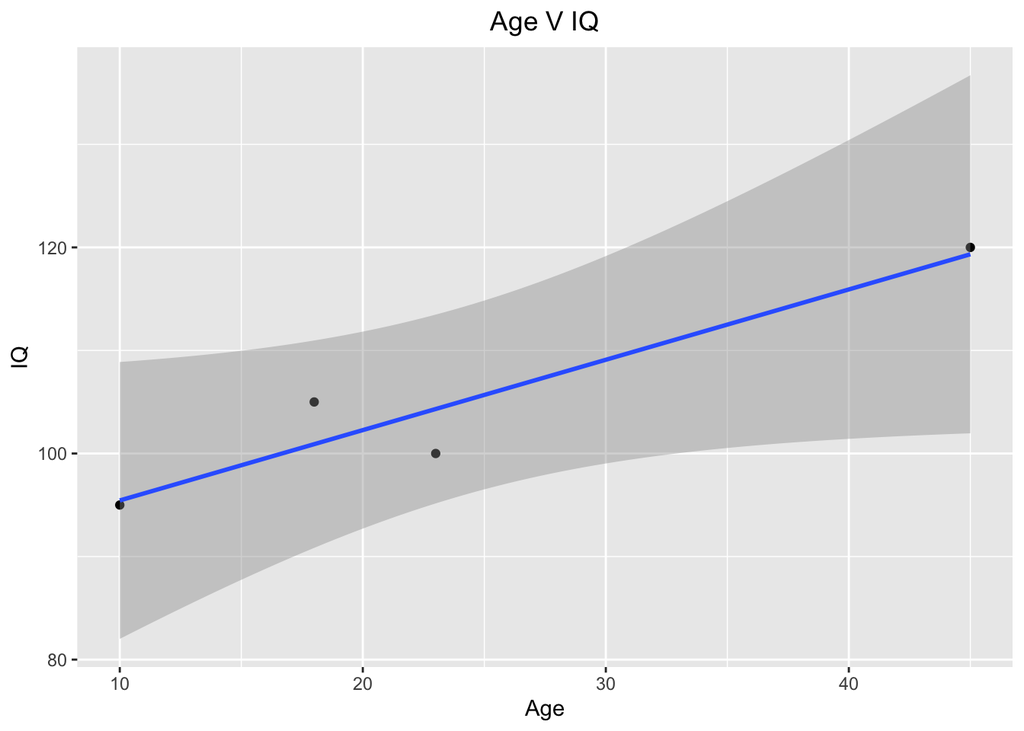

```r
ggplot(data = ageIQ, mapping = aes(x = Age, y = IQ)) + geom_point() + geom_smooth(method = lm) +
    ggtitle("Age V IQ") + theme(plot.title = element_text(hjust = 0.5))
```

## 2

${Cov(x,y) = \frac{1}{4-1}\sum{[(23-24)(100-105)+(18-24)(105-105)....+(45-24)(120-105)]}=153.333333}$

```r
ageIQ.cov <- ageIQ %>% mutate(S = (Age - mean(ageIQ$Age)) * (IQ - mean(ageIQ$IQ))) %>%
    colSums()
c(ageIQ.cov[3]/3, cov(ageIQ$Age, ageIQ$IQ))
```

```
##        S
## 153.3333 153.3333
```

## 3

${r=\frac{153.33333}{14.988*10.80123}=0.947}$

```r
(r <- 153.33333/(sd(ageIQ$Age) * sd(ageIQ$IQ)))
```

```
## [1] 0.9470957
```

```r
c(r, cor(ageIQ$Age, ageIQ$IQ))
```

```
## [1] 0.9470957 0.9470957
```

## 4

${r=\frac{Cov(x,y)}{S_xS_y}=\beta_1\frac{S_x}{S_y}}$ ${\beta_1=\frac{rs_y}{s_x}=\frac{0.9470957*10.80123}{14.98888888}=0.6824926}$ ${\beta_0=\bar{y}-\beta_1\bar{x}}=105-0.6824926*24=88.62018$ ${\hat{y}=88.62018+0.682492x_i}$

```r
(b1 <- r/(sd(ageIQ$Age)/sd(ageIQ$IQ)))
```

```
## [1] 0.6824926
```

```r
(b0 <- mean(ageIQ$IQ) - b1 * mean(ageIQ$Age))
```

```
## [1] 88.62018
```

## 5

${104.3175=(88.62018)+(0.6824926)23}$ ${100.9050=(88.62018)+(0.6824926)18}$ ${95.4451=(88.62018)+(0.6824926)10}$ ${119.3323=(88.62018)+(0.6824926)45}$

```r
(y.i <- ageIQ %>% mutate(`y^i` = b0 + b1 * Age))
```

```
## # A tibble: 4 × 3
##     Age    IQ `y^i`
##   <int> <int> <dbl>
## 1    23   100 104.
## 2    18   105 101.
## 3    10    95  95.4
## 4    45   120 119.
```

## 6

${R^2=\frac{TSS-SSE}{TSS}}$ ${TSS=\sum{(y_i-\bar{y})^2}=\sum{(100−105)^2+(105−105)^2+(95−105)^2+(120−105)^2=350}}$ ${SSE=\sum{(100−104.3175)^2+(105−100.9050)^2+(95−95.4451)^2+(120−119.332)^2}=36.05341}$ ${R^2=\frac{TSS-SSE}{TSS}=\frac{350-36.05341}{350}=0.8969903}$

```r
(TSS <- ageIQ %>% mutate(tss = ((IQ - mean(ageIQ$IQ))^2)))
```

```
## # A tibble: 4 × 3
##     Age    IQ   tss
##   <int> <int> <dbl>
## 1    23   100    25
## 2    18   105     0
## 3    10    95   100
## 4    45   120   225
```

```r
sum(TSS$tss)
```

```
## [1] 350
```

```r
(SSE <- y.i %>% mutate(sse = (IQ - `y^i`)^2))
```

```
## # A tibble: 4 × 4
##     Age    IQ `y^i`    sse
##   <int> <int> <dbl>  <dbl>
## 1    23   100 104.  18.6
## 2    18   105 101.  16.8
## 3    10    95  95.4  0.198
## 4    45   120 119.   0.446
```

```r
sum(SSE$sse)
```

```
## [1] 36.05341
```

```r
(`r^2` <- (sum(TSS$tss) - sum(SSE$sse))/sum(TSS$tss))
```

```
## [1] 0.8969903
```

The R^2 value describes the proportion of the variation in the Y data that is explained by the values for X, in other words, how well the line of best fits predicts the data. The R^2 value is also sometimes called the proportional reduction in error and is described as the proportional reduction of error in the variation in Y that would be explained by the line of best fit. A value of 0.897 suggests that ~89.7% of the variation in Y can be explained by X.

## 7

t-test: H0:${\beta_1=0}$ H1:${\beta_1\neq0}$

${t_{stat}=\frac{\beta_1-\mu_0}{se_{\beta_1}}=\frac{0.6824926-0}{0.1635416}=4.173205}$ ${df=n-k-1=4-1-1=2}$ ${t_{crit}=4.302653}$

```r
(sey <- sqrt(sum(SSE$sse)/2))
```

```
## [1] 4.245787
```

```r
(se <- ageIQ %>% mutate(`xi^2` = Age^2, `xi-x^2` = (Age - mean(ageIQ$Age))^2))
```

```
## # A tibble: 4 × 4
##     Age    IQ `xi^2` `xi-x^2`
##   <int> <int>  <dbl>    <dbl>
## 1    23   100    529        1
## 2    18   105    324       36
## 3    10    95    100      196
## 4    45   120   2025      441
```

```r
(seb0 <- sey * sqrt(sum(se$`xi^2`)/(4 * sum(se$`xi-x^2`))))
```

```
## [1] 4.462319
```

```r
(seb1 <- sey * (1/sqrt(sum(se$`xi-x^2`))))
```

```
## [1] 0.1635416
```

```r
(ts <- (b1 - 0)/seb1)
```

```
## [1] 4.173205
```

```r
qt(0.975, 2)
```

```
## [1] 4.302653
```

We fail to reject the null hypothesis at the 95% confidence level with a 2-tailed test. The positive correlation between age and IQ is not statistically significant. The failure to reject the null in this t-test of significance indicates that despite our Pearson coeffecient r and proportional reduction in error R^2 suggesting that the linear regression model matches the data with reasonable accuracy, the positive correlation between age and IQ is not significant, and the positive correlation in this instance may be due to chance.

## 8

```r
(pv <- 2 * pt(ts, 2, lower.tail = F))
```

```
## [1] 0.05290431
```

## 9

CI = 0.6824926±4.173205∗0.1635416=[1.110223e−16,1.364985]

```r
(ci <- c(b1 + ts * seb1, b1 - ts * seb1))
```

```
## [1] 1.364985e+00 1.110223e-16
```

## 10

```r
summary(lm(IQ ~ Age, data = ageIQ))
```

```
##
## Call:
## lm(formula = IQ ~ Age, data = ageIQ)
##
## Residuals:
##       1       2       3       4
## -4.3175  4.0950 -0.4451  0.6677
##
## Coefficients:
##             Estimate Std. Error t value Pr(>|t|)
## (Intercept)  88.6202     4.4623  19.860  0.00253 **
## Age           0.6825     0.1635   4.173  0.05290 .
## ---
## Signif. codes:  0 '***' 0.001 '**' 0.01 '*' 0.05 '.' 0.1 ' ' 1
##
## Residual standard error: 4.246 on 2 degrees of freedom
## Multiple R-squared:  0.897,  Adjusted R-squared:  0.8455
## F-statistic: 17.42 on 1 and 2 DF,  p-value: 0.0529
```

The results of the lm function agree with the previous calculations.

## 11

The line of best fit and standard error was included in the initial plot.

## 12

r=.947 indicating there is a strong positive correlation between age and IQ. R2=0.897 indicates that approximately 89.7% of the error has been reduced and is explained by the line of best fit. The t-test at the 95% confidence level yielding a p-value of .053 indicates that despite the strength of the correlation indicated by the r and R2 values, this correlation is not signficant, may not actually be as positive as the line of best fit in this trial suggests.